# **Walidacja krzyżowa i bootstrap**

#### **Semestr letni 2022/23**

## **Walidacja krzyżowa**

Używamy zbioru danych `Auto`. Można go wczytać z pliku z pierwszego laboratorium, jest też dostępny w pakiecie `ISLR`.

```r
library(ISLR)
```

**Należy usunąć z niego wiersze zawierające `NA`**.

```r
Auto <- na.omit(Auto)
```

### **Metoda zbioru walidacyjnego**

Tworzymy zbiór uczący z połowy dostępnych obserwacji — reszta będzie stanowić zbiór walidacyjny. Dla zapewnienia powtarzalności obliczeń stosujemy funkcję `set.seed`.

```r
set.seed(1)
n <- nrow(Auto)
train <- sample(n, n / 2)
```

Dopasowujemy model liniowy na zbiorze uczącym, następnie obliczamy MSE dla zbioru walidacyjnego.

```r
Auto_lm <- lm(mpg ~ horsepower, data = Auto, subset = train)
validation_set <- Auto[-train,]
mse <- mean((validation_set$mpg - predict(Auto_lm, validation_set))^2)
mse
```

```
## [1] 23.26601
```

Powtarzamy to samo dla regresji wielomianowej wyższych stopni

```r
for (i in 2:5) {
  Auto_lm_poly <- lm(mpg ~ poly(horsepower, degree = i), data = Auto,
                     subset = train)
  print(mean((validation_set$mpg - predict(Auto_lm_poly, validation_set))^2))
}
```

```
## [1] 18.71646
## [1] 18.79401
## [1] 19.16017
## [1] 19.40812
```

Powtarzamy obliczenia dla innego zbioru walidacyjnego.

```r
set.seed(2)
train <- sample(n, n / 2)
validation_set <- Auto[-train,]
degree_max <- 5
mse <- rep(0, times = degree_max)
for (i in 1:degree_max) {
  Auto_lm <- lm(mpg ~ poly(horsepower, degree = i), data = Auto, subset = train)
  mse[i] <- mean((validation_set$mpg - predict(Auto_lm, validation_set))^2)
}
mse
```

```
## [1] 25.72651 20.43036 20.38533 20.30902 19.79689
```

Wersja powyższego obliczenia dla miłośników programowania funkcyjnego i tych, którzy nie lubią pętli.

```r
compute_mse <- function(degree, train) {
  Auto_lm <- lm(mpg ~ poly(horsepower, degree), data = Auto, subset = train)
  validation_set <- Auto[-train,]
  mean((validation_set$mpg - predict(Auto_lm, validation_set))^2)
}

mse <- sapply(1:degree_max, compute_mse, train = train)
mse
```

```
## [1] 25.72651 20.43036 20.38533 20.30902 19.79689
```

Funkcja `vapply` jest bezpieczniejsza i bywa szybsza od `sapply`, więc przedostatnią instrukcję można zmodyfikować następująco:

```r
mse <- vapply(1:degree_max, compute_mse, FUN.VALUE = numeric(1), train = train)
```

Otrzymane wyniki można zobrazować na wykresie

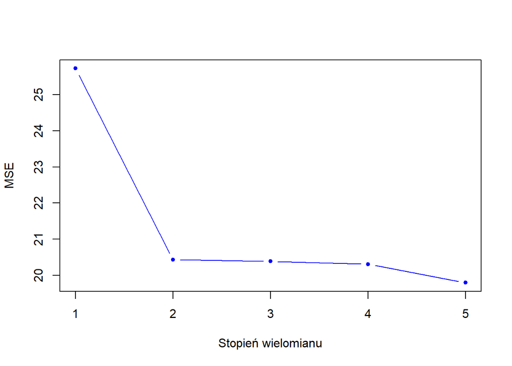

```r
plot(mse, xlab = "Stopień wielomianu", ylab = "MSE", type = "b", pch = 20,
     col = "blue")
```

### **Walidacja krzyżowa *bez jednego* (*leave-one-out*)**

Walidację krzyżową dla uogólnionych modeli liniowych wykonuje funkcja `cv.glm()` z pakietu `boot`.

```r
library(boot)
```

Jej argumentem (`glmfit`) jest obiekt klasy `glm`, więc jeśli chcemy jej użyć do walidacji zwykłych modeli liniowych, musimy je dopasowywać jako uogólnione modele liniowe (z `family = gaussian`, co zresztą jest wartością domyślną). Funkcja `cv.glm()` zwraca listę (zobacz `?cv.glm`), której najbardziej interesującą składawą jest `delta` — wektor o długości 2 zawierający estymatę błędu predykcji w wersji oryginalnej i skorygowaną dla uwzględnienia obciążenia wprowadzanego przez walidację krzyżową inną niż LOOCV.

```r
compute_loocv_mse <- function(degree) {
  Auto_glm <- glm(mpg ~ poly(horsepower, degree), data = Auto)
  cv.glm(Auto, Auto_glm)$delta[1]
}
mse <- sapply(1:degree_max, compute_loocv_mse)
mse
```

```
## [1] 24.23151 19.24821 19.33498 19.42443 19.03321
```

Można też narysować obrazek

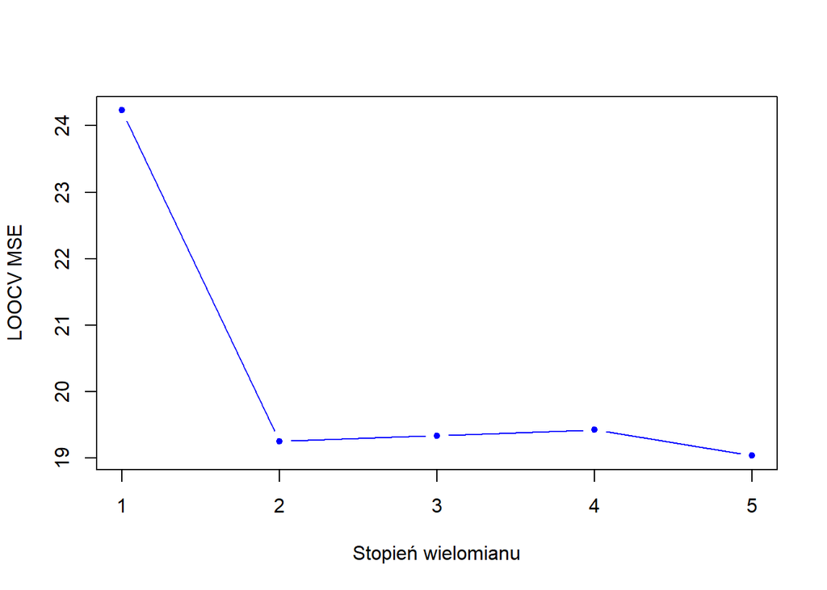

```r
plot(mse, xlab = "Stopień wielomianu", ylab = "LOOCV MSE", type = "b", pch = 20,
     col = "blue")
```

### k-krotna walidacja krzyżowa

Podobnie korzystamy z funkcji `cv.glm()`, tylko teraz jawnie ustawiamy parametr `K` oznaczający liczbę grup (*folds*). Np. dla k=10 wygląda to jak poniżej.

```r
compute_kcv_mse <- function(degree, k) {
  Auto_glm <- glm(mpg ~ poly(horsepower, degree), data = Auto)
  cv.glm(Auto, Auto_glm, K = k)$delta[1]
}
mse <- sapply(1:degree_max, compute_kcv_mse, k = 10)
mse
```

```
## [1] 24.17328 19.27789 19.43292 19.42324 19.03107
```

Oczywiście tym razem wyniki są losowe. Możemy zrobić ich zestawienie dla np. 10 prób.

```r
mse10 <- replicate(10, sapply(1:degree_max, compute_kcv_mse, k = 10))
mse10
```

```
##          [,1]     [,2]     [,3]     [,4]     [,5]     [,6]     [,7]     [,8]
## [1,] 24.27788 24.10007 24.25927 24.31454 24.25059 24.30739 24.26042 24.13090
## [2,] 19.19513 19.23163 19.24065 19.45779 19.16859 19.27467 19.23690 19.15352
## [3,] 19.24164 19.26389 19.47692 19.32020 19.21629 19.28301 19.22254 19.35248
## [4,] 19.48068 19.52346 19.77670 19.58948 19.35854 19.45915 19.58405 19.28010
## [5,] 18.88866 19.58639 19.33305 18.90728 19.02398 18.93032 18.96459 18.90374
##          [,9]    [,10]
## [1,] 24.15632 24.23558
## [2,] 19.18779 19.25120
## [3,] 19.41278 19.22326
## [4,] 19.32840 19.53122
## [5,] 19.05588 19.51447
```

I stosowny obrazek

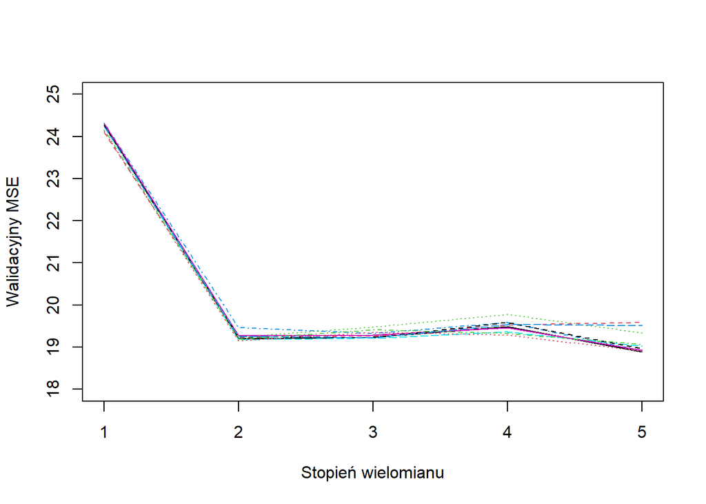

```r
matplot(mse10, pch = 20, type = "l", xlim = c(1, degree_max), ylim = c(18, 25),
        xlab = "Stopień wielomianu", ylab = "Walidacyjny MSE")
```

## **Bootstrap**

Użyjemy metody *bootstrap* do oszacowania błędów standardowych współczynników regresji liniowej. Podstawową funkcją jest tutaj `boot()` z pakietu `boot`. Wymaga ona jako parametru funkcji obliczającej interesującą statystykę dla podanego zbioru danych. Ta ostatnia funkcja powinna akceptować dwa parametry: zbiór danych oraz wektor indeksów (istnieją też inne możliwości: `?boot`).

```r
lm_coefs <- function(data, index = 1:nrow(data)) {
  coef(lm(mpg ~ horsepower, data = Auto, subset = index))
}
```

Funkcja `lm_coefs()` oblicza estymaty współczynników regresji dla zbioru danych typu bootstrap utworzonego z `Auto`:

```r
n <- nrow(Auto)
lm_coefs(Auto, sample(n, n, replace = TRUE))
```

```
## (Intercept)  horsepower
##  40.9138309  -0.1622609
```

Oczywiście jednym z takich zbiorów jest sam oryginał

```r
lm_coefs(Auto)
```

```
## (Intercept)  horsepower
##  39.9358610  -0.1578447
```

Obliczenie błędów standardowych metodą bootstrap z 1000 replikacji wygląda następująco.

```r
boot(Auto, lm_coefs, R = 1000)
```

```
##
## ORDINARY NONPARAMETRIC BOOTSTRAP
##
##
## Call:
## boot(data = Auto, statistic = lm_coefs, R = 1000)
##
##
## Bootstrap Statistics :
##       original        bias    std. error
## t1* 39.9358610  0.0822287915 0.840662953
## t2* -0.1578447 -0.0007697847 0.007265607
```